# A3_Tessmann_Meag

Meag Tessmann

2/10/2020

# Setup & Import

A. Load package and import data. Do NOT load strings as factors. Show the overall structure of the input data. Then, transform all non-numeric variables to factor variables, except Name. Afterwards, show the summary of the input data.

B. Use pairs.panels to show the distributions and correlations of all numeric variables (do not include non-numeric variables such as factor variables).

C. Use the whole dataset except Name to build a linear regression model to estimate Global_Sales. Use the “summary” function to show the summary of the model. (Note: Here, we are using the whole dataset to train the model, instead of a partitioned training set.)

D. Now, partition the dataset for a simple hold-out evaluation: 70% to a training set and 30% to a test set.

E. Show the summary of i) the target variable and ii) all predictors in both the training and test sets, using the “summary” function.

```r
knitr::opts_chunk$set(echo = TRUE)

#############
##### A #####
#############


# Load packages
library(rmarkdown) # knitting
library(rpart)
library(RWeka)
library(caret) # training models
library(tidyverse) # data manipulation
library(skimr) # data preview
library(rminer)
library(matrixStats)
```

```r
library("scales") # plotting monies
library("knitr") # fancy tables
library(kableExtra)
library(psych) #pairs panelse
# Import data
sales <- read.csv('sales_filtered.csv', fileEncoding="latin1", stringsAsFactors = FALSE)

skim(sales)
```

```
## Skim summary statistics
##  n obs: 6942
##  n variables: 9
##
## ── Variable type:character ─────────────────────────────────────────────────
##  variable missing complete    n min max empty n_unique
##     Genre       0     6942 6942   4  12     0       12
##      Name       0     6942 6942   2  71     0     4431
##  Platform       0     6942 6942   2   4     0       17
##    Rating       0     6942 6942   1   7     0        5
##
## ── Variable type:integer ───────────────────────────────────────────────────
##      variable missing complete    n   mean     sd p0 p25 p50 p75  p100     hist
##  Critic_Count       0     6942 6942  28.5   18.91  3  14  24  39   113 ▇▇▅▃▁▁▁▁
##  Critic_Score       0     6942 6942  70.09  13.82 13  62  72  80    98 ▁▁▁▂▅▇▇▂
##    User_Count       0     6942 6942 161.8  552.75  4  11  26  86 10665 ▇▁▁▁▁▁▁▁
##    User_Score       0     6942 6942  70.8   14.4   5  64  74  81    95 ▁▁▁▁▂▅▇▃
##
## ── Variable type:numeric ───────────────────────────────────────────────────
##      variable missing complete    n mean   sd   p0  p25  p50  p75 p100     hist
##  Global_Sales       0     6942 6942 0.63 0.94 0.01 0.11 0.28 0.72 7.15 ▇▁▁▁▁▁▁▁
```

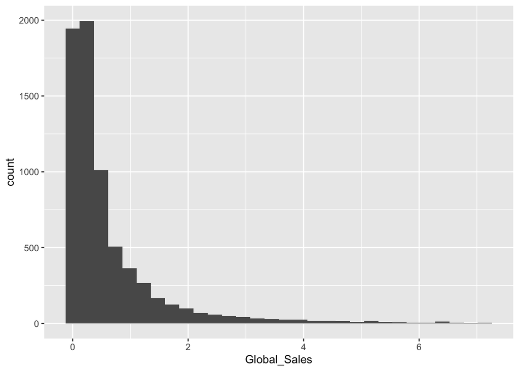

```r
#  There are 3 factor variables, 4 integer variables, and 1 numeric variable which looks right skewed with potentially an upper outlier or two.

# change factor variables to factors
sales <- sales %>%
  mutate(
    Genre = factor(Genre),
    Platform = factor(Platform),
    Rating = factor(Rating),
  )

# plot sales to check for skewness and outliers - looks like it's has a really long tail
ggplot(sales, aes(Global_Sales)) +
  geom_histogram()
```

```r
# confirm changes
summary(sales)
```

```
##      Name              Platform             Genre          Rating
##  Length:6942        PS2    :1154   Action      :1666   E      :2087
##  Class :character   X360   : 866   Sports      : 967   E10+   : 943
##  Mode  :character   PS3    : 780   Shooter     : 867   M      :1429
##                     PC     : 700   Role-Playing: 715   missing:  70
##                     XB     : 579   Racing      : 589   T      :2413
##                     Wii    : 477   Platform    : 401
##                     (Other):2386   (Other)     :1737
##   Critic_Score    Critic_Count     User_Score     User_Count
##  Min.   :13.00   Min.   :  3.0   Min.   : 5.0   Min.   :    4.0
##  1st Qu.:62.00   1st Qu.: 14.0   1st Qu.:64.0   1st Qu.:   11.0
##  Median :72.00   Median : 24.0   Median :74.0   Median :   26.0
##  Mean   :70.09   Mean   : 28.5   Mean   :70.8   Mean   :  161.8
##  3rd Qu.:80.00   3rd Qu.: 39.0   3rd Qu.:81.0   3rd Qu.:   86.0
##  Max.   :98.00   Max.   :113.0   Max.   :95.0   Max.   :10665.0
##
##   Global_Sales
##  Min.   :0.0100
##  1st Qu.:0.1100
##  Median :0.2800
##  Mean   :0.6322
##  3rd Qu.:0.7200
##  Max.   :7.1500
##
```

```r
#############
##### B #####
#############



# Take all numeric variables
num_vars <- sales %>%
  select_if(is.numeric)

# get correlation matrix
cor(num_vars)
```

```
##              Critic_Score Critic_Count User_Score User_Count Global_Sales
## Critic_Score    1.0000000    0.3827201 0.58479750 0.25086271    0.3455400
## Critic_Count    0.3827201    1.0000000 0.19334521 0.34662800    0.3829813
## User_Score      0.5847975    0.1933452 1.00000000 0.02685421    0.1482295
## User_Count      0.2508627    0.3466280 0.02685421 1.00000000    0.3118339
## Global_Sales    0.3455400    0.3829813 0.14822946 0.31183388    1.0000000
```

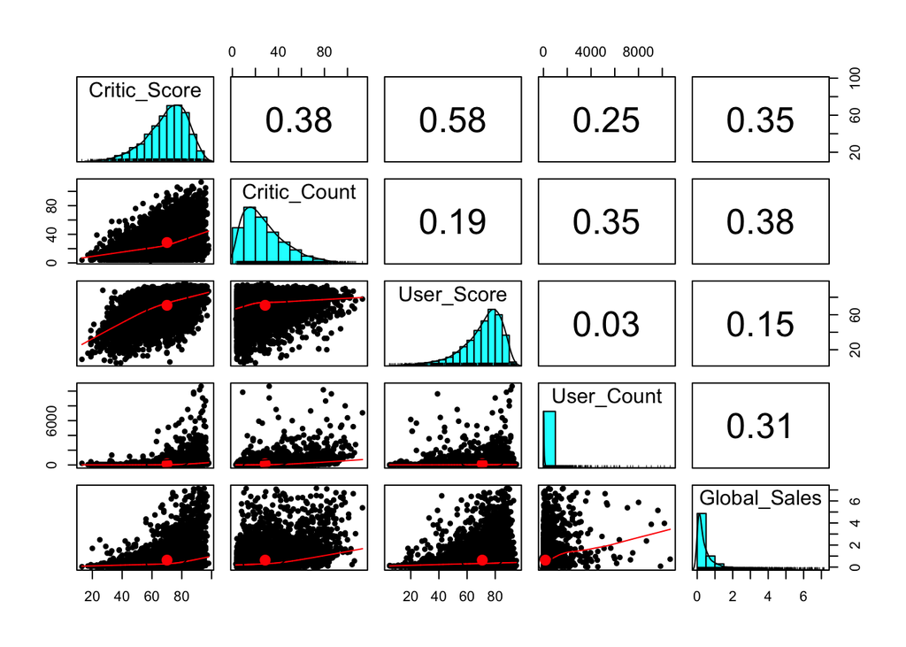

```r
# plot pair panels
pairs.panels(num_vars)
```

```r
#############
##### C #####
#############

# create full training set, leaving out name
train_full <- sales %>%
  select(-Name)

# train a linear model with full data set
model_full_set <- lm(Global_Sales ~., data = train_full)
# check model summaries
model_full_set
```

```
##
## Call:
## lm(formula = Global_Sales ~ ., data = train_full)
##
## Coefficients:
##       (Intercept)         PlatformDC         PlatformDS        PlatformGBA
##        -0.6774957         -0.2397662          0.2055979          0.1756760
##        PlatformGC         PlatformPC         PlatformPS        PlatformPS2
##         0.0184045         -0.5566467          0.7894495          0.3479077
##       PlatformPS3        PlatformPS4        PlatformPSP        PlatformPSV
##         0.1990983         -0.0552277          0.0641980         -0.1989845
##       PlatformWii       PlatformWiiU       PlatformX360         PlatformXB
##         0.3560973          0.0228378          0.0598979         -0.1427353
##      PlatformXOne     GenreAdventure      GenreFighting          GenreMisc
##         0.1245381         -0.1982139         -0.0515109          0.1136311
##     GenrePlatform        GenrePuzzle        GenreRacing  GenreRole-Playing
##        -0.0531671         -0.2766684         -0.0875449         -0.1776552
##      GenreShooter    GenreSimulation        GenreSports      GenreStrategy
##        -0.0476248          0.0850668         -0.0783073         -0.2728219
##        RatingE10+            RatingM      Ratingmissing            RatingT
##        -0.1160047         -0.2096759         -0.0948515         -0.1736467
##      Critic_Score       Critic_Count         User_Score         User_Count
##         0.0188396          0.0133652         -0.0051128          0.0004295
```

```r
summary(model_full_set)
```

```
##
## Call:
## lm(formula = Global_Sales ~ ., data = train_full)
##
## Residuals:
##     Min      1Q  Median      3Q     Max
## -3.9874 -0.4201 -0.1385  0.1899  5.9293
##
## Coefficients:
##                     Estimate Std. Error t value Pr(>|t|)
## (Intercept)       -6.775e-01  8.509e-02  -7.962 1.96e-15 ***
## PlatformDC        -2.398e-01  2.188e-01  -1.096 0.273302
## PlatformDS         2.056e-01  7.290e-02   2.820 0.004812 **
## PlatformGBA        1.757e-01  8.191e-02   2.145 0.031998 *
## PlatformGC         1.840e-02  7.639e-02   0.241 0.809608
## PlatformPC        -5.566e-01  7.264e-02  -7.664 2.06e-14 ***
## PlatformPS         7.894e-01  9.154e-02   8.624  < 2e-16 ***
## PlatformPS2        3.479e-01  6.827e-02   5.096 3.56e-07 ***
## PlatformPS3        1.991e-01  6.972e-02   2.856 0.004308 **
## PlatformPS4       -5.523e-02  8.130e-02  -0.679 0.496944
## PlatformPSP        6.420e-02  7.477e-02   0.859 0.390578
## PlatformPSV       -1.990e-01  9.575e-02  -2.078 0.037730 *
## PlatformWii        3.561e-01  7.263e-02   4.903 9.66e-07 ***
## PlatformWiiU       2.284e-02  1.039e-01   0.220 0.826094
## PlatformX360       5.990e-02  6.948e-02   0.862 0.388657
## PlatformXB        -1.427e-01  7.235e-02  -1.973 0.048551 *
## PlatformXOne       1.245e-01  8.887e-02   1.401 0.161143
## GenreAdventure    -1.982e-01  5.201e-02  -3.811 0.000139 ***
## GenreFighting     -5.151e-02  4.550e-02  -1.132 0.257593
## GenreMisc          1.136e-01  4.552e-02   2.497 0.012565 *
## GenrePlatform     -5.317e-02  4.603e-02  -1.155 0.248125
## GenrePuzzle       -2.767e-01  7.695e-02  -3.595 0.000326 ***
## GenreRacing       -8.754e-02  4.043e-02  -2.165 0.030401 *
## GenreRole-Playing -1.777e-01  3.584e-02  -4.958 7.31e-07 ***
## GenreShooter      -4.762e-02  3.373e-02  -1.412 0.158042
## GenreSimulation    8.507e-02  5.038e-02   1.689 0.091333 .
## GenreSports       -7.831e-02  3.824e-02  -2.048 0.040604 *
## GenreStrategy     -2.728e-01  5.244e-02  -5.202 2.03e-07 ***
## RatingE10+        -1.160e-01  3.368e-02  -3.445 0.000575 ***
## RatingM           -2.097e-01  3.741e-02  -5.606 2.16e-08 ***
## Ratingmissing     -9.485e-02  9.795e-02  -0.968 0.332912
## RatingT           -1.736e-01  2.987e-02  -5.813 6.40e-09 ***
## Critic_Score       1.884e-02  9.715e-04  19.392  < 2e-16 ***
## Critic_Count       1.337e-02  6.540e-04  20.438  < 2e-16 ***
## User_Score        -5.113e-03  8.699e-04  -5.878 4.35e-09 ***
## User_Count         4.295e-04  1.993e-05  21.543  < 2e-16 ***
## ---
## Signif. codes:  0 '***' 0.001 '**' 0.01 '*' 0.05 '.' 0.1 ' ' 1
##
## Residual standard error: 0.778 on 6906 degrees of freedom
## Multiple R-squared:  0.3256, Adjusted R-squared:  0.3221
## F-statistic: 95.25 on 35 and 6906 DF,  p-value: < 2.2e-16
```

```r
#############
##### D #####
#############


# create train, test partitions

n_obs <- nrow(sales)

set.seed(500)
train_sample <- sample(n_obs, (n_obs*.7))
train <- train_full[train_sample,]
test <- train_full[-train_sample,]


#############
##### E #####
#############



# check target variable distro across test, train, full sets
summary(train$Global_Sales)
```

```
##    Min. 1st Qu.  Median    Mean 3rd Qu.    Max.
##  0.0100  0.1100  0.2800  0.6254  0.7100  7.1500
```

```r
summary(test$Global_Sales)
```

```
##    Min. 1st Qu.  Median    Mean 3rd Qu.    Max.
##  0.0100  0.1100  0.2800  0.6481  0.7400  6.7400
```

```r
summary(train_full$Global_Sales)
```

```
##    Min. 1st Qu.  Median    Mean 3rd Qu.    Max.
##  0.0100  0.1100  0.2800  0.6322  0.7200  7.1500
```

```r
# check summaries
summary(train)
```

```
##     Platform             Genre          Rating      Critic_Score
##  PS2    : 802   Action      :1152   E      :1456   Min.   :13.00
##  X360   : 605   Sports      : 671   E10+   : 671   1st Qu.:62.00
##  PS3    : 541   Shooter     : 601   M      : 994   Median :72.00
##  PC     : 503   Role-Playing: 492   missing:  49   Mean   :70.14
##  XB     : 410   Racing      : 418   T      :1689   3rd Qu.:80.00
##  Wii    : 340   Platform    : 296                  Max.   :98.00
##  (Other):1658   (Other)     :1229
##   Critic_Count      User_Score      User_Count       Global_Sales
##  Min.   :  3.00   Min.   : 5.00   Min.   :    4.0   Min.   :0.0100
##  1st Qu.: 14.00   1st Qu.:64.00   1st Qu.:   11.0   1st Qu.:0.1100
##  Median : 24.00   Median :74.00   Median :   26.0   Median :0.2800
##  Mean   : 28.51   Mean   :70.89   Mean   :  167.3   Mean   :0.6254
##  3rd Qu.: 39.00   3rd Qu.:81.00   3rd Qu.:   87.0   3rd Qu.:0.7100
##  Max.   :113.00   Max.   :95.00   Max.   :10665.0   Max.   :7.1500
##
```

```r
summary(test)
```

```
##     Platform            Genre         Rating     Critic_Score
##  PS2    :352   Action      :514   E      :631   Min.   :19.00
##  X360   :261   Sports      :296   E10+   :272   1st Qu.:62.00
##  PS3    :239   Shooter     :266   M      :435   Median :72.00
##  PC     :197   Role-Playing:223   missing: 21   Mean   :69.98
##  XB     :169   Racing      :171   T      :724   3rd Qu.:80.00
##  DS     :148   Fighting    :121                 Max.   :97.00
##  (Other):717   (Other)     :492
##   Critic_Count      User_Score     User_Count      Global_Sales
##  Min.   :  4.00   Min.   : 5.0   Min.   :   4.0   Min.   :0.0100
##  1st Qu.: 14.00   1st Qu.:63.0   1st Qu.:  11.0   1st Qu.:0.1100
##  Median : 24.00   Median :74.0   Median :  27.0   Median :0.2800
##  Mean   : 28.48   Mean   :70.6   Mean   : 148.9   Mean   :0.6481
##  3rd Qu.: 39.00   3rd Qu.:81.0   3rd Qu.:  85.0   3rd Qu.:0.7400
##  Max.   :107.00   Max.   :94.0   Max.   :9629.0   Max.   :6.7400
##
```

```r
summary(train_full)
```

```
##     Platform             Genre          Rating      Critic_Score
##  PS2    :1154   Action      :1666   E      :2087   Min.   :13.00
##  X360   : 866   Sports      : 967   E10+   : 943   1st Qu.:62.00
##  PS3    : 780   Shooter     : 867   M      :1429   Median :72.00
##  PC     : 700   Role-Playing: 715   missing:  70   Mean   :70.09
##  XB     : 579   Racing      : 589   T      :2413   3rd Qu.:80.00
##  Wii    : 477   Platform    : 401                  Max.   :98.00
##  (Other):2386   (Other)     :1737
##   Critic_Count     User_Score     User_Count       Global_Sales
##  Min.   :  3.0   Min.   : 5.0   Min.   :    4.0   Min.   :0.0100
##  1st Qu.: 14.0   1st Qu.:64.0   1st Qu.:   11.0   1st Qu.:0.1100
##  Median : 24.0   Median :74.0   Median :   26.0   Median :0.2800
##  Mean   : 28.5   Mean   :70.8   Mean   :  161.8   Mean   :0.6322
##  3rd Qu.: 39.0   3rd Qu.:81.0   3rd Qu.:   86.0   3rd Qu.:0.7200
##  Max.   :113.0   Max.   :95.0   Max.   :10665.0   Max.   :7.1500
##
```

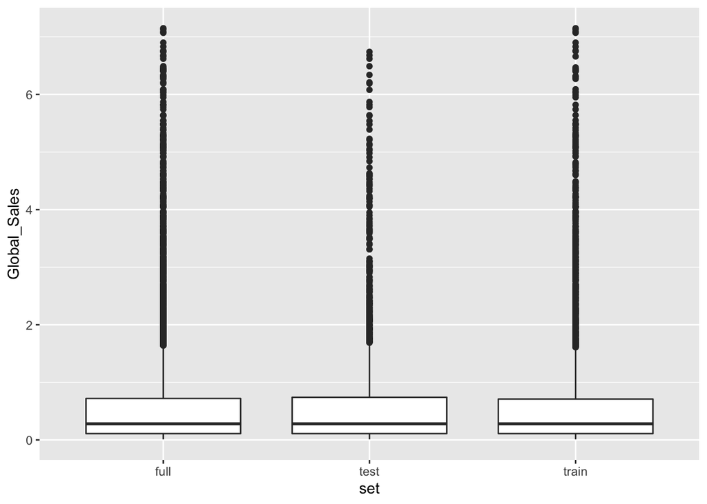

```r
#compare target variable histograms in test, train, and full population
compare_test <- test %>%
  select(Global_Sales) %>%
  mutate(set = "test")
compare_train <- train %>%
  select(Global_Sales) %>%
  mutate(set = "train")
all_sets <- sales %>%
  select(Global_Sales) %>%
  mutate(set = "full")
all_sets = rbind(all_sets, compare_test, compare_train)

ggplot(all_sets, aes(set, Global_Sales)) +
  geom_boxplot()
```

# LM, rpart, M5P Models

A. Train the three models (i.e., lm, rpart and M5P) using the training dataset obtained from 1.D. Use the default settings of these functions throughout this assignment (i.e., do not specify any additional options when using the lm, rpart, or M5P functions). Show the summary of each of the models.

B. For each of the models built in 2.A, generate the model’s evaluation metrics (i.e., MAE, RMSE, MAPE, RMSPE, RAE, RRSE, and R2) with the test and training sets, separately.

```r
#############
##### A #####
#############

# train lm model
model_lm <- lm(Global_Sales~., data=train)

#train rpart model
model_rpart <- rpart(Global_Sales~., data=train)

# train M5P model
model_m5p <- M5P(Global_Sales~., data=train)

#show summaries (not sure if you prefer the model or the summary() summarization)
model_lm
```

```
##
## Call:
## lm(formula = Global_Sales ~ ., data = train)
##
## Coefficients:
##       (Intercept)         PlatformDC         PlatformDS        PlatformGBA
##        -0.6526872         -0.2025627          0.1947819          0.2519189
##        PlatformGC         PlatformPC         PlatformPS        PlatformPS2
##         0.0665369         -0.5376502          0.8016766          0.3546842
##       PlatformPS3        PlatformPS4        PlatformPSP        PlatformPSV
##         0.2239945         -0.0429303          0.0697468         -0.1719079
##       PlatformWii       PlatformWiiU       PlatformX360         PlatformXB
##         0.3947693          0.1550163          0.1099952         -0.0807817
##      PlatformXOne     GenreAdventure      GenreFighting          GenreMisc
##         0.1986715         -0.1781455         -0.0068110          0.0778780
##     GenrePlatform        GenrePuzzle        GenreRacing  GenreRole-Playing
##        -0.0185697         -0.2065273         -0.0640357         -0.1373221
##      GenreShooter    GenreSimulation        GenreSports      GenreStrategy
##        -0.0456333          0.0940655         -0.0805353         -0.2582118
##        RatingE10+            RatingM      Ratingmissing            RatingT
##        -0.1223009         -0.2097259         -0.0733950         -0.1605834
##      Critic_Score       Critic_Count         User_Score         User_Count
##         0.0188397          0.0130328         -0.0060113          0.0004141
```

```r
model_rpart
```

```
## n= 4859
##
## node), split, n, deviance, yval
##       * denotes terminal node
##
##  1) root 4859 4243.1210 0.6253571
##    2) User_Count< 65.5 3426 1019.8830 0.4097023
##      4) User_Count< 25.5 2378  363.3321 0.3158537 *
##      5) User_Count>=25.5 1048  588.0818 0.6226527
##       10) Platform=3DS,DC,GC,PC,PS,PS3,PS4,PSP,PSV,WiiU,X360,XOne 646  149.8921 0.4276316 *
##       11) Platform=DS,GBA,PS2,Wii,XB 402  374.1380 0.9360448 *
##    3) User_Count>=65.5 1433 2682.9740 1.1409420
##      6) Platform=3DS,DC,PC,PSV 451  191.6203 0.3650333 *
##      7) Platform=DS,GBA,GC,PS,PS2,PS3,PS4,PSP,Wii,WiiU,X360,XB,XOne 982 2095.1370 1.4972910
##       14) User_Count< 515 811 1096.4320 1.1889770
##         28) Platform=PS3,PS4,PSP,WiiU,X360,XB,XOne 595  442.9597 0.9466218
##           56) Critic_Score< 80.5 354  141.8103 0.7029379 *
##           57) Critic_Score>=80.5 241  249.2506 1.3045640 *
##         29) Platform=DS,GBA,GC,PS,PS2,Wii 216  522.2559 1.8565740
##           58) Genre=Action,Adventure,Role-Playing,Shooter,Simulation,Strategy 142  253.4700 1.5130990 *
##           59) Genre=Fighting,Misc,Platform,Puzzle,Racing,Sports 74  219.8866 2.5156760 *
##       15) User_Count>=515 171  555.9904 2.9595320
##         30) Critic_Score< 91.5 134  319.7443 2.6064930 *
##         31) Critic_Score>=91.5 37  159.0588 4.2381080 *
```

```r
model_m5p
```

```
## M5 pruned model tree:
## (using smoothed linear models)
##
## User_Count <= 26.5 :
## |   Platform=DS,GBA,PS2,Wii,WiiU,X360,PS4,PS3,XOne,PS <= 0.5 : LM1 (842/26.718%)
## |   Platform=DS,GBA,PS2,Wii,WiiU,X360,PS4,PS3,XOne,PS >  0.5 :
## |   |   Critic_Score <= 66.5 :
## |   |   |   Platform=WiiU,X360,PS4,PS3,XOne,PS <= 0.5 : LM2 (567/38.067%)
## |   |   |   Platform=WiiU,X360,PS4,PS3,XOne,PS >  0.5 : LM3 (280/20.694%)
## |   |   Critic_Score >  66.5 :
## |   |   |   User_Count <= 12.5 :
## |   |   |   |   Platform=PS2,Wii,WiiU,X360,PS4,PS3,XOne,PS <= 0.5 :
## |   |   |   |   |   User_Score <= 79.5 :
## |   |   |   |   |   |   User_Score <= 75.5 :
## |   |   |   |   |   |   |   Critic_Score <= 71.5 :
## |   |   |   |   |   |   |   |   User_Score <= 68 :
## |   |   |   |   |   |   |   |   |   User_Score <= 58.5 : LM4 (6/23.383%)
## |   |   |   |   |   |   |   |   |   User_Score >  58.5 : LM5 (14/18.716%)
## |   |   |   |   |   |   |   |   User_Score >  68 : LM6 (15/24.527%)
## |   |   |   |   |   |   |   Critic_Score >  71.5 : LM7 (25/14.624%)
## |   |   |   |   |   |   User_Score >  75.5 : LM8 (16/76.692%)
## |   |   |   |   |   User_Score >  79.5 : LM9 (38/21.976%)
## |   |   |   |   Platform=PS2,Wii,WiiU,X360,PS4,PS3,XOne,PS >  0.5 : LM10 (229/31.768%)
## |   |   |   User_Count >  12.5 :
## |   |   |   |   Critic_Count <= 19.5 :
## |   |   |   |   |   Platform=WiiU,X360,PS4,PS3,XOne,PS <= 0.5 :
## |   |   |   |   |   |   User_Score <= 79.5 :
## |   |   |   |   |   |   |   User_Score <= 67.5 : LM11 (12/39.725%)
## |   |   |   |   |   |   |   User_Score >  67.5 :
## |   |   |   |   |   |   |   |   User_Count <= 15.5 : LM12 (19/80.122%)
## |   |   |   |   |   |   |   |   User_Count >  15.5 : LM13 (23/76.339%)
## |   |   |   |   |   |   User_Score >  79.5 : LM14 (47/32.373%)
## |   |   |   |   |   Platform=WiiU,X360,PS4,PS3,XOne,PS >  0.5 : LM15 (39/30.432%)
## |   |   |   |   Critic_Count >  19.5 : LM16 (262/45.06%)
## User_Count >  26.5 :
## |   Critic_Score <= 80.5 :
## |   |   Platform=DC,XB,PSP,GC,3DS,DS,GBA,PS2,Wii,WiiU,X360,PS4,PS3,XOne,PS <= 0.5 :
## |   |   |   Critic_Score <= 69.5 : LM17 (107/12.904%)
## |   |   |   Critic_Score >  69.5 : LM18 (199/42.228%)
## |   |   Platform=DC,XB,PSP,GC,3DS,DS,GBA,PS2,Wii,WiiU,X360,PS4,PS3,XOne,PS >  0.5 :
```

[output cut: 1131 more lines]

```
##  - 0.0035 * Genre=Fighting,Role-Playing,Sports,Shooter,Misc,Platform
##  - 0.003 * Genre=Role-Playing,Sports,Shooter,Misc,Platform
##  + 0.0024 * Genre=Sports,Shooter,Misc,Platform
##  + 0.0044 * Genre=Misc,Platform
##  - 0.0035 * Genre=Platform
##  + 1.4609 * Rating=T,E,M
##  + 0.0512 * Rating=E,M
##  - 0.8614 * Rating=M
##  + 0.0555 * Critic_Score
##  + 0.0014 * Critic_Count
##  - 0.0015 * User_Score
##  + 0.0005 * User_Count
##  - 3.0955
##
## Number of Rules : 33
```

```r
summary(model_lm)
```

```
##
## Call:
## lm(formula = Global_Sales ~ ., data = train)
##
## Residuals:
##     Min      1Q  Median      3Q     Max
## -3.7994 -0.4169 -0.1432  0.1849  5.9591
##
## Coefficients:
##                     Estimate Std. Error t value Pr(>|t|)
## (Intercept)       -6.527e-01  1.041e-01  -6.267 4.00e-10 ***
## PlatformDC        -2.026e-01  2.385e-01  -0.849  0.39566
## PlatformDS         1.948e-01  8.887e-02   2.192  0.02845 *
## PlatformGBA        2.519e-01  9.880e-02   2.550  0.01081 *
## PlatformGC         6.654e-02  9.253e-02   0.719  0.47212
## PlatformPC        -5.377e-01  8.796e-02  -6.112 1.06e-09 ***
## PlatformPS         8.017e-01  1.128e-01   7.106 1.37e-12 ***
## PlatformPS2        3.547e-01  8.305e-02   4.271 1.99e-05 ***
## PlatformPS3        2.240e-01  8.499e-02   2.636  0.00842 **
## PlatformPS4       -4.293e-02  9.924e-02  -0.433  0.66533
## PlatformPSP        6.975e-02  9.021e-02   0.773  0.43946
## PlatformPSV       -1.719e-01  1.160e-01  -1.482  0.13838
## PlatformWii        3.948e-01  8.799e-02   4.487 7.41e-06 ***
## PlatformWiiU       1.550e-01  1.294e-01   1.198  0.23114
## PlatformX360       1.100e-01  8.473e-02   1.298  0.19430
## PlatformXB        -8.078e-02  8.773e-02  -0.921  0.35722
## PlatformXOne       1.987e-01  1.059e-01   1.876  0.06069 .
## GenreAdventure    -1.781e-01  6.055e-02  -2.942  0.00328 **
## GenreFighting     -6.811e-03  5.476e-02  -0.124  0.90102
## GenreMisc          7.788e-02  5.459e-02   1.427  0.15377
## GenrePlatform     -1.857e-02  5.401e-02  -0.344  0.73101
## GenrePuzzle       -2.065e-01  9.043e-02  -2.284  0.02242 *
## GenreRacing       -6.404e-02  4.791e-02  -1.336  0.18146
## GenreRole-Playing -1.373e-01  4.325e-02  -3.175  0.00151 **
## GenreShooter      -4.563e-02  4.038e-02  -1.130  0.25844
## GenreSimulation    9.407e-02  5.935e-02   1.585  0.11306
## GenreSports       -8.054e-02  4.556e-02  -1.768  0.07720 .
## GenreStrategy     -2.582e-01  6.211e-02  -4.157 3.28e-05 ***
## RatingE10+        -1.223e-01  3.999e-02  -3.058  0.00224 **
## RatingM           -2.097e-01  4.458e-02  -4.704 2.62e-06 ***
## Ratingmissing     -7.339e-02  1.172e-01  -0.626  0.53134
## RatingT           -1.606e-01  3.589e-02  -4.474 7.85e-06 ***
## Critic_Score       1.884e-02  1.156e-03  16.291  < 2e-16 ***
## Critic_Count       1.303e-02  7.801e-04  16.706  < 2e-16 ***
## User_Score        -6.011e-03  1.048e-03  -5.736 1.03e-08 ***
## User_Count         4.141e-04  2.297e-05  18.028  < 2e-16 ***
## ---
## Signif. codes:  0 '***' 0.001 '**' 0.01 '*' 0.05 '.' 0.1 ' ' 1
##
## Residual standard error: 0.7753 on 4823 degrees of freedom
## Multiple R-squared:  0.3168, Adjusted R-squared:  0.3119
## F-statistic: 63.91 on 35 and 4823 DF,  p-value: < 2.2e-16
```

```r
summary(model_rpart)
```

```
## Call:
## rpart(formula = Global_Sales ~ ., data = train)
##   n= 4859
##
##           CP nsplit rel error    xerror       xstd
## 1 0.12732710      0 1.0000000 1.0001280 0.05571868
## 2 0.09885787      1 0.8726729 0.8817671 0.04706998
## 3 0.03092442      3 0.6749572 0.7123102 0.03894480
## 4 0.01819117      4 0.6440327 0.6781863 0.03565689
## 5 0.01613646      5 0.6258416 0.6813750 0.03582665
## 6 0.01509543      6 0.6097051 0.6710433 0.03550075
## 7 0.01223128      7 0.5946097 0.6557623 0.03507349
## 8 0.01152435      8 0.5823784 0.6431591 0.03417157
## 9 0.01000000      9 0.5708541 0.6412287 0.03397524
##
## Variable importance
##   User_Count     Platform Critic_Count Critic_Score        Genre       Rating
##           41           28           11           10            5            3
##   User_Score
##            3
##
## Node number 1: 4859 observations,    complexity param=0.1273271
##   mean=0.6253571, MSE=0.8732499
##   left son=2 (3426 obs) right son=3 (1433 obs)
##   Primary splits:
##       User_Count   < 65.5  to the left,  improve=0.12732710, (0 missing)
##       Critic_Score < 82.5  to the left,  improve=0.12212040, (0 missing)
##       Critic_Count < 60.5  to the left,  improve=0.11766050, (0 missing)
##       Platform     splits as  LLLLLLRRRRLLRRRLR, improve=0.04079771, (0 missing)
##       User_Score   < 74.5  to the left,  improve=0.01813882, (0 missing)
##   Surrogate splits:
##       Critic_Count < 45.5  to the left,  agree=0.797, adj=0.313, (0 split)
##       Platform     splits as  LLLLLRLLLRLRLRLLR, agree=0.776, adj=0.241, (0 split)
##       Critic_Score < 83.5  to the left,  agree=0.761, adj=0.188, (0 split)
##       Rating       splits as  LLRLL, agree=0.735, adj=0.100, (0 split)
##
## Node number 2: 3426 observations,    complexity param=0.01613646
##   mean=0.4097023, MSE=0.2976891
##   left son=4 (2378 obs) right son=5 (1048 obs)
##   Primary splits:
```

[output cut: 128 more lines]

```
##
## Node number 31: 37 observations
##   mean=4.238108, MSE=4.298886
##
## Node number 56: 354 observations
##   mean=0.7029379, MSE=0.4005942
##
## Node number 57: 241 observations
##   mean=1.304564, MSE=1.034235
##
## Node number 58: 142 observations
##   mean=1.513099, MSE=1.785
##
## Node number 59: 74 observations
##   mean=2.515676, MSE=2.971441
```

```r
summary(model_m5p)
```

```
##
## === Summary ===
##
## Correlation coefficient                  0.7526
## Mean absolute error                      0.3601
## Root mean squared error                  0.6159
## Relative absolute error                 61.3977 %
## Root relative squared error             65.9107 %
## Total Number of Instances             4859
```

```r
#############
##### B #####
#############


# predict on train, test sets for each model
predict_lm_train <- predict(model_lm, train)
predict_lm_test <- predict(model_lm, test)

predict_rpart_train <- predict(model_rpart, train)
predict_rpart_test <- predict(model_rpart, test)

predict_m5p_train <- predict(model_m5p, train)
predict_m5p_test <- predict(model_m5p, test)

# show stats for test/train for each model
stats <- as.matrix(rbind(
  mmetric(train$Global_Sales, predict_lm_train, metric=c("MAE","RMSE","MAPE","RMSPE","RAE", "RRSE", "COR", "R2")),
  mmetric(test$Global_Sales, predict_lm_test, metric=c("MAE","RMSE","MAPE","RMSPE","RAE", "RRSE", "COR", "R2")),
  mmetric(train$Global_Sales, predict_rpart_train, metric=c("MAE","RMSE","MAPE","RMSPE","RAE", "RRSE", "COR", "R2")),
  mmetric(test$Global_Sales, predict_rpart_test, metric=c("MAE","RMSE","MAPE","RMSPE","RAE", "RRSE", "COR", "R2")),
  mmetric(train$Global_Sales, predict_m5p_train, metric=c("MAE","RMSE","MAPE","RMSPE","RAE", "RRSE", "COR", "R2")),
  mmetric(test$Global_Sales, predict_m5p_test, metric=c("MAE","RMSE","MAPE","RMSPE","RAE", "RRSE", "COR", "R2"))
))
rownames(stats) <- c("lm (train)", "lm (test)", "rpart (train)", "rpart (test)", "m5p (train)", "m5p (test)")

# fancy taable
kable(stats, digits=2) %>%
  kable_styling(bootstrap_options = c("striped", "hover"))
```

|  | MAE | RMSE | MAPE | RMSPE | RAE | RRSE | COR | R2 |
| --- | --- | --- | --- | --- | --- | --- | --- | --- |
| lm (train) | 0.48 | 0.77 | 306.65 | 71.70 | 82.37 | 82.65 | 0.56 | 0.32 |
| lm (test) | 0.49 | 0.79 | 326.85 | 85.95 | 78.65 | 81.28 | 0.58 | 0.34 |
| rpart (train) | 0.43 | 0.71 | 290.40 | 68.48 | 74.02 | 75.55 | 0.66 | 0.43 |
| rpart (test) | 0.47 | 0.78 | 308.53 | 78.04 | 75.25 | 80.02 | 0.60 | 0.36 |
| m5p (train) | 0.36 | 0.62 | 172.61 | 43.28 | 61.40 | 65.91 | 0.75 | 0.57 |
| m5p (test) | 0.41 | 0.72 | 210.88 | 67.96 | 65.38 | 74.26 | 0.67 | 0.45 |

# Cross Validation

A. Define a named function for cross validation (for numeric prediction) that generates a table of the evaluation metrics for each fold and that also generates the means and standard deviations of each metric. Refer to the Week 4 tutorial file for details.

B. Use the function defined in 3.A to generate 5-fold cross validation results of lm, rpart and M5P models.

```r
#############
##### A #####
#############



# create cross validation function for k-fold validation

cv_function <- function(df, target, nFolds, seedVal, prediction_method, metrics_list)
{
  # Create folds
  set.seed(seedVal)
  folds = createFolds(df[,target],nFolds)

  # Perform cross validation
  cv_results <- lapply(folds, function(x)
  {
    test_target <- df[x,target]
    test_input  <- df[x,-target]

    train_target <- df[-x,target]
    train_input <- df[-x,-target]

    prediction_model <- prediction_method(train_target~.,train_input)
    pred <- predict(prediction_model,test_input)
    return(mmetric(test_target,pred,metrics_list))
  })

  # Generate means and sds and show cv results, means and sds using kable
  cv_results_m <- as.matrix(as.data.frame(cv_results))
  cv_mean<- as.matrix(rowMeans(cv_results_m))
  cv_sd <- as.matrix(rowSds(cv_results_m))
  colnames(cv_mean) <- "Mean"
  colnames(cv_sd) <- "Sd"
  cv_all <- cbind(cv_results_m, cv_mean, cv_sd)
  kable(t(cv_all), digits=2) %>%
    kable_styling(bootstrap_options = c("striped", "hover")) %>%
    row_spec(6:7, bold=T, background="#e0eaf6")
}




#############
##### B #####
#############

# set parameters
df <- train_full
target <- which(colnames(train)=="Global_Sales")
nFolds <- 5
seedVal <- 500
metrics_list <- c("MAE","RMSE","MAPE","RMSPE","RAE","RRSE","R2")

cv_function(df, target, nFolds, seedVal, lm, metrics_list)
```

|  | MAE | RMSE | MAPE | RMSPE | RAE | RRSE | R2 |
| --- | --- | --- | --- | --- | --- | --- | --- |
| Fold1 | 0.51 | 0.83 | 330.15 | 77.49 | 82.27 | 82.95 | 0.31 |
| Fold2 | 0.49 | 0.77 | 310.14 | 70.98 | 84.45 | 83.00 | 0.31 |
| Fold3 | 0.48 | 0.74 | 326.23 | 88.42 | 83.27 | 82.50 | 0.32 |
| Fold4 | 0.48 | 0.74 | 308.37 | 72.77 | 82.52 | 82.93 | 0.31 |
| Fold5 | 0.50 | 0.82 | 313.39 | 76.66 | 78.79 | 81.89 | 0.33 |
| Mean | 0.49 | 0.78 | 317.65 | 77.26 | 82.26 | 82.66 | 0.32 |
| Sd | 0.01 | 0.04 | 9.88 | 6.80 | 2.12 | 0.47 | 0.01 |

```r
cv_function(df, target, nFolds, seedVal, rpart, metrics_list)
```

|  | MAE | RMSE | MAPE | RMSPE | RAE | RRSE | R2 |
| --- | --- | --- | --- | --- | --- | --- | --- |
| Fold1 | 0.47 | 0.79 | 276.29 | 63.05 | 75.44 | 79.12 | 0.38 |
| Fold2 | 0.45 | 0.74 | 281.45 | 62.14 | 77.42 | 79.77 | 0.36 |
| Fold3 | 0.43 | 0.71 | 304.40 | 85.44 | 75.18 | 78.45 | 0.39 |
| Fold4 | 0.45 | 0.74 | 296.52 | 69.39 | 77.85 | 81.97 | 0.34 |
| Fold5 | 0.47 | 0.78 | 299.77 | 70.59 | 74.09 | 77.74 | 0.40 |
| Mean | 0.45 | 0.75 | 291.69 | 70.12 | 75.99 | 79.41 | 0.37 |
| Sd | 0.02 | 0.03 | 12.17 | 9.34 | 1.59 | 1.62 | 0.02 |

```r
cv_function(df, target, nFolds, seedVal, M5P, metrics_list)
```

|  | MAE | RMSE | MAPE | RMSPE | RAE | RRSE | R2 |
| --- | --- | --- | --- | --- | --- | --- | --- |
| Fold1 | 0.45 | 0.79 | 223.49 | 55.01 | 72.93 | 79.49 | 0.46 |
| Fold2 | 0.37 | 0.66 | 163.29 | 41.12 | 64.59 | 71.43 | 0.49 |
| Fold3 | 0.40 | 0.67 | 217.71 | 86.85 | 69.65 | 75.02 | 0.45 |
| Fold4 | 0.60 | 1.11 | 383.38 | 155.41 | 104.34 | 123.86 | 0.07 |
| Fold5 | 0.43 | 0.75 | 230.32 | 66.26 | 67.63 | 74.98 | 0.44 |
| Mean | 0.45 | 0.80 | 243.64 | 80.93 | 75.83 | 84.96 | 0.38 |
| Sd | 0.09 | 0.18 | 82.52 | 44.87 | 16.23 | 21.94 | 0.18 |

# Quadratic of User Count

Improve the models by adding a quadratic term of User_Count:

A. Create and add the quadratic term of User_Count, e.g., User_Count_Squared, to the entire dataset (Do NOT use the partitioned dataset).

B. Build an lm model using the whole dataset that includes User_Count_Squared to predict Global_Sales. (Do NOT split the data into training and test sets. Use the whole dataset.) Show the summary of this lm model.

C. Use the cross validation function defined in 3.A to generate 5-fold cross validation results of the lm, rpart and M5P models with User_Count_Squared included.

```r
#############
##### A #####
#############


# create new dataset with quadratic user count variable
train_full_quad <- train_full %>%
  mutate(
    User_Count_Squared = User_Count^2
  )
summary(train_full_quad)
```

```
##     Platform             Genre          Rating      Critic_Score
##  PS2    :1154   Action      :1666   E      :2087   Min.   :13.00
##  X360   : 866   Sports      : 967   E10+   : 943   1st Qu.:62.00
##  PS3    : 780   Shooter     : 867   M      :1429   Median :72.00
##  PC     : 700   Role-Playing: 715   missing:  70   Mean   :70.09
##  XB     : 579   Racing      : 589   T      :2413   3rd Qu.:80.00
##  Wii    : 477   Platform    : 401                  Max.   :98.00
##  (Other):2386   (Other)     :1737
##   Critic_Count     User_Score     User_Count       Global_Sales
##  Min.   :  3.0   Min.   : 5.0   Min.   :    4.0   Min.   :0.0100
##  1st Qu.: 14.0   1st Qu.:64.0   1st Qu.:   11.0   1st Qu.:0.1100
##  Median : 24.0   Median :74.0   Median :   26.0   Median :0.2800
##  Mean   : 28.5   Mean   :70.8   Mean   :  161.8   Mean   :0.6322
##  3rd Qu.: 39.0   3rd Qu.:81.0   3rd Qu.:   86.0   3rd Qu.:0.7200
##  Max.   :113.0   Max.   :95.0   Max.   :10665.0   Max.   :7.1500
##
##  User_Count_Squared
##  Min.   :       16
##  1st Qu.:      121
##  Median :      676
##  Mean   :   331673
##  3rd Qu.:     7396
##  Max.   :113742225
##
```

```r
#############
##### B #####
#############

model_lm_quad <- lm(Global_Sales~., data=train_full_quad)
model_lm_quad
```

```
##
## Call:
## lm(formula = Global_Sales ~ ., data = train_full_quad)
##
## Coefficients:
##        (Intercept)          PlatformDC          PlatformDS         PlatformGBA
##         -5.959e-01          -2.530e-01           2.084e-01           1.711e-01
##         PlatformGC          PlatformPC          PlatformPS         PlatformPS2
##          2.392e-02          -7.059e-01           7.569e-01           3.571e-01
##        PlatformPS3         PlatformPS4         PlatformPSP         PlatformPSV
##          1.883e-01          -1.236e-01           8.069e-02          -2.096e-01
##        PlatformWii        PlatformWiiU        PlatformX360          PlatformXB
##          3.485e-01          -4.785e-02           7.271e-02          -1.005e-01
##       PlatformXOne      GenreAdventure       GenreFighting           GenreMisc
##          3.438e-02          -1.823e-01          -2.955e-02           1.426e-01
##      GenrePlatform         GenrePuzzle         GenreRacing   GenreRole-Playing
##         -5.292e-02          -2.366e-01          -7.079e-02          -1.782e-01
##       GenreShooter     GenreSimulation         GenreSports       GenreStrategy
##         -4.463e-02           1.239e-01          -4.965e-02          -2.420e-01
##         RatingE10+             RatingM       Ratingmissing             RatingT
##         -1.059e-01          -2.614e-01          -6.014e-02          -1.694e-01
##       Critic_Score        Critic_Count          User_Score          User_Count
##          1.682e-02           1.073e-02          -4.024e-03           1.048e-03
## User_Count_Squared
##         -9.685e-08
```

```r
summary(model_lm_quad)
```

```
##
## Call:
## lm(formula = Global_Sales ~ ., data = train_full_quad)
##
## Residuals:
##     Min      1Q  Median      3Q     Max
## -3.2517 -0.4080 -0.1350  0.1917  5.8794
##
## Coefficients:
##                      Estimate Std. Error t value Pr(>|t|)
## (Intercept)        -5.959e-01  8.351e-02  -7.135 1.06e-12 ***
## PlatformDC         -2.530e-01  2.144e-01  -1.180 0.238001
## PlatformDS          2.084e-01  7.143e-02   2.917 0.003543 **
## PlatformGBA         1.711e-01  8.025e-02   2.132 0.033078 *
## PlatformGC          2.392e-02  7.484e-02   0.320 0.749264
## PlatformPC         -7.059e-01  7.171e-02  -9.844  < 2e-16 ***
## PlatformPS          7.569e-01  8.971e-02   8.437  < 2e-16 ***
## PlatformPS2         3.571e-01  6.690e-02   5.337 9.73e-08 ***
## PlatformPS3         1.883e-01  6.832e-02   2.756 0.005866 **
## PlatformPS4        -1.236e-01  7.976e-02  -1.549 0.121389
## PlatformPSP         8.069e-02  7.326e-02   1.101 0.270808
## PlatformPSV        -2.096e-01  9.382e-02  -2.234 0.025485 *
## PlatformWii         3.485e-01  7.117e-02   4.897 9.97e-07 ***
## PlatformWiiU       -4.785e-02  1.019e-01  -0.469 0.638757
## PlatformX360        7.271e-02  6.808e-02   1.068 0.285535
## PlatformXB         -1.005e-01  7.093e-02  -1.417 0.156574
## PlatformXOne        3.438e-02  8.723e-02   0.394 0.693476
## GenreAdventure     -1.823e-01  5.096e-02  -3.576 0.000351 ***
## GenreFighting      -2.955e-02  4.460e-02  -0.663 0.507601
## GenreMisc           1.426e-01  4.463e-02   3.195 0.001405 **
## GenrePlatform      -5.292e-02  4.510e-02  -1.173 0.240715
## GenrePuzzle        -2.366e-01  7.543e-02  -3.136 0.001719 **
## GenreRacing        -7.079e-02  3.963e-02  -1.786 0.074087 .
## GenreRole-Playing  -1.782e-01  3.511e-02  -5.077 3.94e-07 ***
## GenreShooter       -4.463e-02  3.305e-02  -1.350 0.176933
## GenreSimulation     1.239e-01  4.941e-02   2.508 0.012178 *
## GenreSports        -4.965e-02  3.750e-02  -1.324 0.185601
## GenreStrategy      -2.420e-01  5.142e-02  -4.706 2.57e-06 ***
## RatingE10+         -1.059e-01  3.300e-02  -3.210 0.001335 **
## RatingM            -2.614e-01  3.678e-02  -7.107 1.30e-12 ***
## Ratingmissing      -6.014e-02  9.600e-02  -0.626 0.531043
## RatingT            -1.694e-01  2.927e-02  -5.787 7.48e-09 ***
## Critic_Score        1.682e-02  9.593e-04  17.532  < 2e-16 ***
## Critic_Count        1.073e-02  6.593e-04  16.273  < 2e-16 ***
## User_Score         -4.024e-03  8.547e-04  -4.708 2.55e-06 ***
## User_Count          1.048e-03  4.134e-05  25.362  < 2e-16 ***
## User_Count_Squared -9.685e-08  5.701e-09 -16.989  < 2e-16 ***
## ---
## Signif. codes:  0 '***' 0.001 '**' 0.01 '*' 0.05 '.' 0.1 ' ' 1
##
## Residual standard error: 0.7623 on 6905 degrees of freedom
## Multiple R-squared:  0.3526, Adjusted R-squared:  0.3493
## F-statistic: 104.5 on 36 and 6905 DF,  p-value: < 2.2e-16
```

```r
#############
##### C #####
#############

# switch data frame to dataset containing quadratic term
df <- train_full_quad

# run 5-fold cross validation for 3 models: lm, rpart, and m5p
cv_function(df, target, nFolds, seedVal, lm, metrics_list)
```

|  | MAE | RMSE | MAPE | RMSPE | RAE | RRSE | R2 |
| --- | --- | --- | --- | --- | --- | --- | --- |
| Fold1 | 0.50 | 0.80 | 340.54 | 83.06 | 80.53 | 79.99 | 0.36 |
| Fold2 | 0.48 | 0.75 | 325.29 | 78.91 | 82.68 | 80.73 | 0.35 |
| Fold3 | 0.47 | 0.73 | 338.40 | 93.86 | 81.85 | 81.42 | 0.34 |
| Fold4 | 0.48 | 0.74 | 323.61 | 78.38 | 82.03 | 82.56 | 0.32 |
| Fold5 | 0.49 | 0.81 | 323.68 | 83.02 | 78.26 | 80.73 | 0.35 |
| Mean | 0.48 | 0.76 | 330.30 | 83.45 | 81.07 | 81.09 | 0.34 |
| Sd | 0.01 | 0.03 | 8.43 | 6.23 | 1.76 | 0.97 | 0.01 |

```r
cv_function(df, target, nFolds, seedVal, rpart, metrics_list)
```

|  | MAE | RMSE | MAPE | RMSPE | RAE | RRSE | R2 |
| --- | --- | --- | --- | --- | --- | --- | --- |
| Fold1 | 0.47 | 0.79 | 276.29 | 63.05 | 75.44 | 79.12 | 0.38 |
| Fold2 | 0.45 | 0.74 | 281.45 | 62.14 | 77.42 | 79.77 | 0.36 |
| Fold3 | 0.43 | 0.71 | 304.40 | 85.44 | 75.18 | 78.45 | 0.39 |
| Fold4 | 0.45 | 0.74 | 296.52 | 69.39 | 77.85 | 81.97 | 0.34 |
| Fold5 | 0.47 | 0.78 | 299.77 | 70.59 | 74.09 | 77.74 | 0.40 |
| Mean | 0.45 | 0.75 | 291.69 | 70.12 | 75.99 | 79.41 | 0.37 |
| Sd | 0.02 | 0.03 | 12.17 | 9.34 | 1.59 | 1.62 | 0.02 |

```r
cv_function(df, target, nFolds, seedVal, M5P, metrics_list)
```

|  | MAE | RMSE | MAPE | RMSPE | RAE | RRSE | R2 |
| --- | --- | --- | --- | --- | --- | --- | --- |
| Fold1 | 0.42 | 0.70 | 199.03 | 45.85 | 66.58 | 70.17 | 0.51 |
| Fold2 | 1.70 | 16.07 | 419.03 | 239.00 | 294.23 | 1737.77 | 0.06 |
| Fold3 | 0.40 | 0.67 | 217.60 | 86.82 | 69.64 | 75.03 | 0.45 |
| Fold4 | 0.39 | 0.68 | 203.62 | 51.22 | 66.84 | 75.66 | 0.43 |
| Fold5 | 0.43 | 0.75 | 230.78 | 66.32 | 67.72 | 74.99 | 0.44 |
| Mean | 0.67 | 3.77 | 254.01 | 97.84 | 113.00 | 406.72 | 0.38 |
| Sd | 0.58 | 6.87 | 93.09 | 80.49 | 101.31 | 744.08 | 0.18 |

# Log of User Count

Improve the models with the log term of User_Count (Do not use the quadratic term of User_Count from Part 4):

A. Create and add the natural log of User_Count, e.g., log_User_Count, to the original entire dataset. (Hint: Use log() function without specifying the base. Run ?log to find out more.)

B. Build an lm model using the whole data set that includes log_User_Count and excludes User_Count. (Do NOT split the data into training and test sets. Use the whole dataset.) Show the summary of this lm model.

C. Use the cross validation function defined in 3.A to generate 5-fold cross validation results of the lm, rpart and M5P models with log_User_Count included and User_Count excluded.

```r
#############
##### A #####
#############


# create new dataset with log of user count variable (and remove user_count)
train_full_log <- train_full %>%
  mutate(
    User_Count_Log = log(User_Count)
  ) %>%
  select(-User_Count)
summary(train_full_log)
```

```
##     Platform             Genre          Rating      Critic_Score
##  PS2    :1154   Action      :1666   E      :2087   Min.   :13.00
##  X360   : 866   Sports      : 967   E10+   : 943   1st Qu.:62.00
##  PS3    : 780   Shooter     : 867   M      :1429   Median :72.00
##  PC     : 700   Role-Playing: 715   missing:  70   Mean   :70.09
##  XB     : 579   Racing      : 589   T      :2413   3rd Qu.:80.00
##  Wii    : 477   Platform    : 401                  Max.   :98.00
##  (Other):2386   (Other)     :1737
##   Critic_Count     User_Score    Global_Sales    User_Count_Log
##  Min.   :  3.0   Min.   : 5.0   Min.   :0.0100   Min.   :1.386
##  1st Qu.: 14.0   1st Qu.:64.0   1st Qu.:0.1100   1st Qu.:2.398
##  Median : 24.0   Median :74.0   Median :0.2800   Median :3.258
##  Mean   : 28.5   Mean   :70.8   Mean   :0.6322   Mean   :3.559
##  3rd Qu.: 39.0   3rd Qu.:81.0   3rd Qu.:0.7200   3rd Qu.:4.454
##  Max.   :113.0   Max.   :95.0   Max.   :7.1500   Max.   :9.275
##
```

```r
#############
##### B #####
#############

# train and summarize lm model using log user count var
model_lm_log <- lm(Global_Sales~., data=train_full_log)
model_lm_log
```

```
##
## Call:
## lm(formula = Global_Sales ~ ., data = train_full_log)
##
## Coefficients:
##       (Intercept)         PlatformDC         PlatformDS        PlatformGBA
##         -1.261266          -0.245611           0.458567           0.503769
##        PlatformGC         PlatformPC         PlatformPS        PlatformPS2
##          0.330975          -0.863682           0.875174           0.563758
##       PlatformPS3        PlatformPS4        PlatformPSP        PlatformPSV
##          0.205842          -0.199349           0.324284          -0.296080
##       PlatformWii       PlatformWiiU       PlatformX360         PlatformXB
##          0.504680          -0.241337           0.118152           0.316051
##      PlatformXOne     GenreAdventure      GenreFighting          GenreMisc
##         -0.162518          -0.115374          -0.047703           0.249053
##     GenrePlatform        GenrePuzzle        GenreRacing  GenreRole-Playing
##         -0.129035          -0.099980          -0.066741          -0.273689
##      GenreShooter    GenreSimulation        GenreSports      GenreStrategy
##         -0.056615           0.187425           0.008905          -0.233083
##        RatingE10+            RatingM      Ratingmissing            RatingT
##         -0.081934          -0.388988          -0.137030          -0.209753
##      Critic_Score       Critic_Count         User_Score     User_Count_Log
##          0.010317           0.003742          -0.004605           0.396222
```

```r
summary(model_lm_log)
```

```
##
## Call:
## lm(formula = Global_Sales ~ ., data = train_full_log)
##
## Residuals:
##     Min      1Q  Median      3Q     Max
## -2.3245 -0.4063 -0.1002  0.2100  5.5598
##
## Coefficients:
##                     Estimate Std. Error t value Pr(>|t|)
## (Intercept)       -1.2612656  0.0810391 -15.564  < 2e-16 ***
## PlatformDC        -0.2456114  0.2064519  -1.190  0.23421
## PlatformDS         0.4585672  0.0690709   6.639 3.40e-11 ***
## PlatformGBA        0.5037690  0.0776676   6.486 9.41e-11 ***
## PlatformGC         0.3309749  0.0724988   4.565 5.08e-06 ***
## PlatformPC        -0.8636823  0.0693048 -12.462  < 2e-16 ***
## PlatformPS         0.8751741  0.0863202  10.139  < 2e-16 ***
## PlatformPS2        0.5637582  0.0646484   8.720  < 2e-16 ***
## PlatformPS3        0.2058419  0.0657701   3.130  0.00176 **
## PlatformPS4       -0.1993485  0.0768392  -2.594  0.00950 **
## PlatformPSP        0.3242844  0.0708881   4.575 4.85e-06 ***
## PlatformPSV       -0.2960805  0.0903676  -3.276  0.00106 **
## PlatformWii        0.5046800  0.0685856   7.358 2.08e-13 ***
## PlatformWiiU      -0.2413371  0.0983963  -2.453  0.01420 *
## PlatformX360       0.1181524  0.0655726   1.802  0.07161 .
## PlatformXB         0.3160514  0.0694881   4.548 5.50e-06 ***
## PlatformXOne      -0.1625180  0.0843366  -1.927  0.05402 .
## GenreAdventure    -0.1153740  0.0491315  -2.348  0.01889 *
## GenreFighting     -0.0477028  0.0429181  -1.111  0.26640
## GenreMisc          0.2490531  0.0431243   5.775 8.02e-09 ***
## GenrePlatform     -0.1290354  0.0434756  -2.968  0.00301 **
## GenrePuzzle       -0.0999796  0.0728049  -1.373  0.16972
## GenreRacing       -0.0667412  0.0381478  -1.750  0.08024 .
## GenreRole-Playing -0.2736888  0.0339601  -8.059 8.99e-16 ***
## GenreShooter      -0.0566153  0.0318231  -1.779  0.07527 .
## GenreSimulation    0.1874252  0.0476420   3.934 8.44e-05 ***
## GenreSports        0.0089053  0.0361795   0.246  0.80558
## GenreStrategy     -0.2330831  0.0494823  -4.710 2.52e-06 ***
## RatingE10+        -0.0819343  0.0317859  -2.578  0.00997 **
## RatingM           -0.3889878  0.0357932 -10.868  < 2e-16 ***
## Ratingmissing     -0.1370299  0.0923533  -1.484  0.13792
## RatingT           -0.2097532  0.0281787  -7.444 1.10e-13 ***
## Critic_Score       0.0103170  0.0009579  10.771  < 2e-16 ***
## Critic_Count       0.0037421  0.0006943   5.390 7.28e-08 ***
## User_Score        -0.0046048  0.0008191  -5.622 1.96e-08 ***
## User_Count_Log     0.3962218  0.0106823  37.091  < 2e-16 ***
## ---
## Signif. codes:  0 '***' 0.001 '**' 0.01 '*' 0.05 '.' 0.1 ' ' 1
##
## Residual standard error: 0.7339 on 6906 degrees of freedom
## Multiple R-squared:  0.3998, Adjusted R-squared:  0.3968
## F-statistic: 131.4 on 35 and 6906 DF,  p-value: < 2.2e-16
```

```r
#############
##### C #####
#############

# switch data frame var to use data set including log user count
df <- train_full_log

# run 5-fold cross validation for lm, rpart, and m5p models
cv_function(df, target, nFolds, seedVal, lm, metrics_list)
```

|  | MAE | RMSE | MAPE | RMSPE | RAE | RRSE | R2 |
| --- | --- | --- | --- | --- | --- | --- | --- |
| Fold1 | 0.59 | 0.76 | 19.55 | 2.75 | 47.84 | 49.28 | 0.76 |
| Fold2 | 0.59 | 0.76 | 20.08 | 2.84 | 48.44 | 49.88 | 0.75 |
| Fold3 | 0.59 | 0.75 | 19.76 | 2.80 | 48.35 | 49.65 | 0.75 |
| Fold4 | 0.60 | 0.77 | 19.74 | 2.79 | 49.06 | 50.34 | 0.75 |
| Fold5 | 0.59 | 0.75 | 19.72 | 2.75 | 48.29 | 49.19 | 0.76 |
| Mean | 0.59 | 0.76 | 19.77 | 2.79 | 48.40 | 49.67 | 0.75 |
| Sd | 0.01 | 0.01 | 0.19 | 0.04 | 0.44 | 0.47 | 0.00 |

```r
cv_function(df, target, nFolds, seedVal, rpart, metrics_list)
```

|  | MAE | RMSE | MAPE | RMSPE | RAE | RRSE | R2 |
| --- | --- | --- | --- | --- | --- | --- | --- |
| Fold1 | 0.76 | 0.96 | 24.78 | 3.37 | 61.45 | 61.68 | 0.62 |
| Fold2 | 0.76 | 0.97 | 24.90 | 3.42 | 62.28 | 63.90 | 0.59 |
| Fold3 | 0.72 | 0.92 | 23.88 | 3.30 | 59.45 | 60.95 | 0.63 |
| Fold4 | 0.75 | 0.96 | 24.46 | 3.35 | 61.40 | 63.00 | 0.60 |
| Fold5 | 0.78 | 1.01 | 25.23 | 3.54 | 63.45 | 66.24 | 0.56 |
| Mean | 0.75 | 0.96 | 24.65 | 3.40 | 61.60 | 63.15 | 0.60 |
| Sd | 0.02 | 0.03 | 0.51 | 0.09 | 1.46 | 2.07 | 0.03 |

```r
cv_function(df, target, nFolds, seedVal, M5P, metrics_list)
```

|  | MAE | RMSE | MAPE | RMSPE | RAE | RRSE | R2 |
| --- | --- | --- | --- | --- | --- | --- | --- |
| Fold1 | 0.58 | 0.74 | 20.61 | 2.94 | 47.07 | 47.55 | 0.81 |
| Fold2 | 0.54 | 0.69 | 18.22 | 2.55 | 44.37 | 45.51 | 0.79 |
| Fold3 | 0.61 | 0.76 | 21.74 | 3.07 | 50.23 | 50.33 | 0.80 |
| Fold4 | 0.58 | 0.73 | 20.11 | 2.88 | 47.16 | 47.92 | 0.78 |
| Fold5 | 0.54 | 0.70 | 17.86 | 2.52 | 44.01 | 45.61 | 0.79 |
| Mean | 0.57 | 0.72 | 19.71 | 2.79 | 46.57 | 47.38 | 0.80 |
| Sd | 0.03 | 0.03 | 1.64 | 0.24 | 2.52 | 1.98 | 0.01 |